# Boletim Epidemiológico — Zika

# 4 Tendência temporal

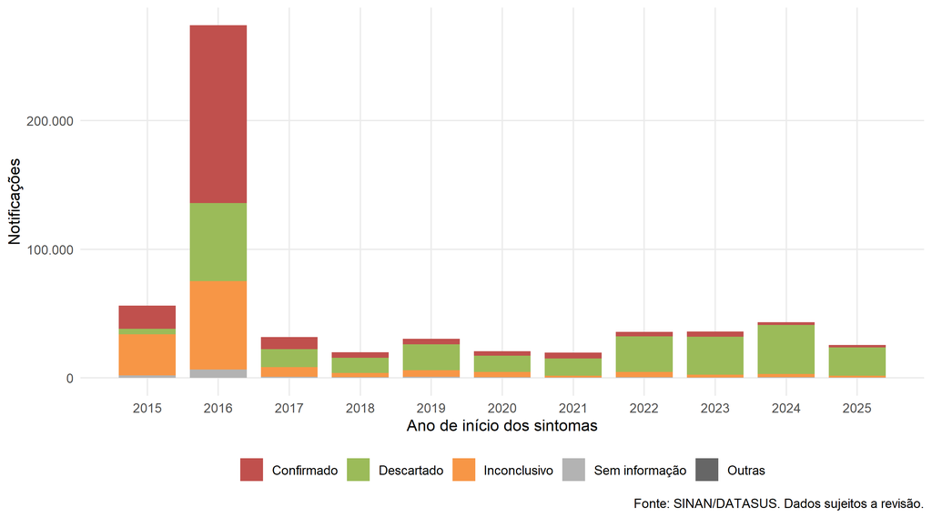

Figura 1. Notificações de zika por ano de início dos sintomas, segundo classificação final. Brasil.

Nesta figura é importante notar que nos anos após a epidemia a maioria dos casos suspeitos são classifcados como “Descartado”. Isso pode estar associado a coincidência de sintomas com outros agravos (dengue, chinkunguya, gripes). Outra hipótese é que o sistema de vigilância está configurado para ter alta sensibilidade.

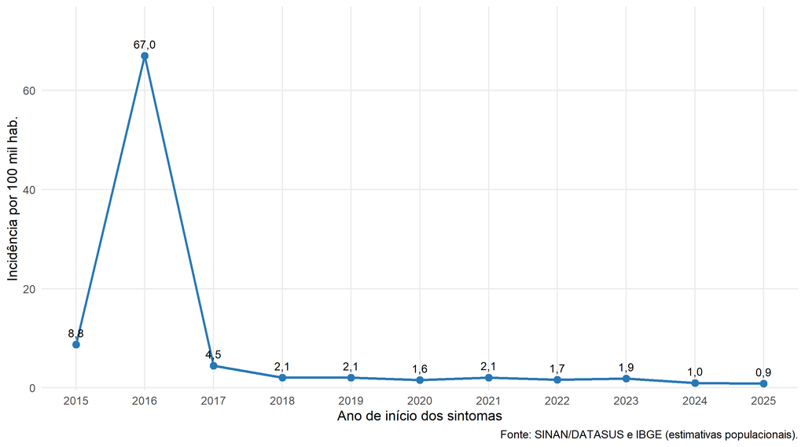

Figura 2. Incidência de zika (casos confirmados por 100 mil habitantes) por ano de início dos sintomas. Brasil.

Nesta imagem fica ainda mais evidente como a epidemia de 2016 foi um ponto fora da curva.

# 5 Sazonalidade

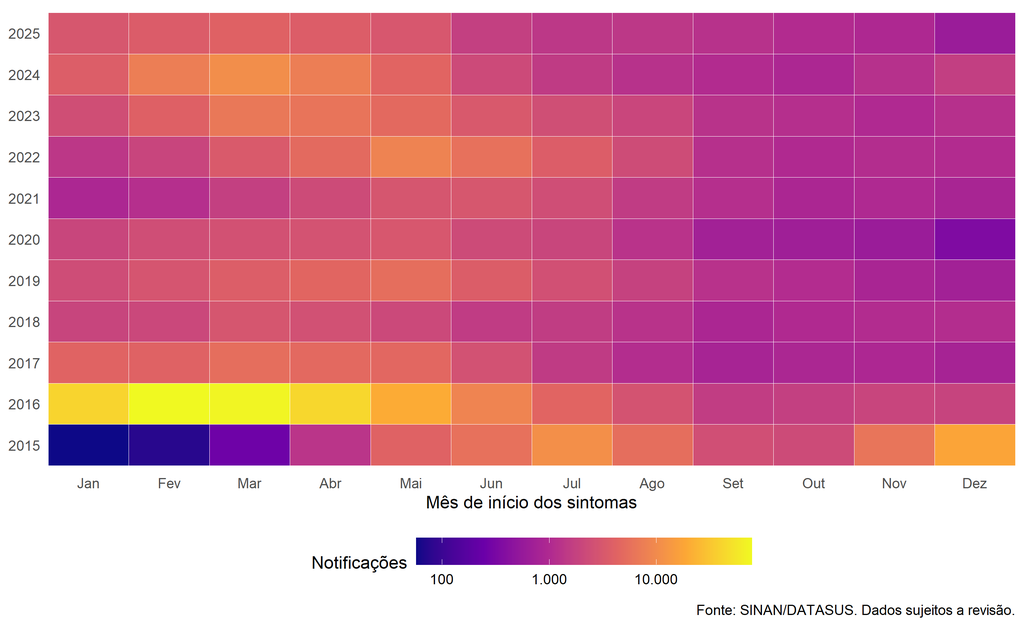

Figura 3. Notificações de zika por mês e ano de início dos sintomas (escala logarítmica). Brasil.

A incidência de Zika parece ser maior entre Janeiro e Maio, embora em alguns anos se prolongue até Julho. Este período coincide com o ciclo de vida do *Aedes*.

# 6 Distribuição espacial

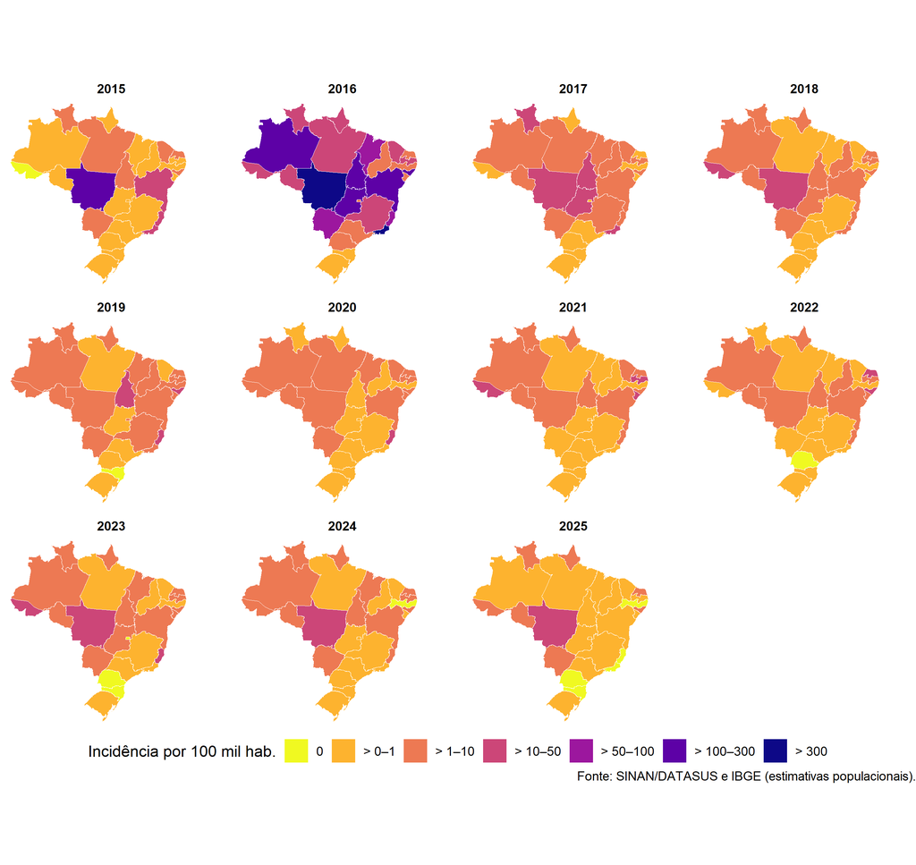

Figura 4. Incidência de zika (casos confirmados por 100 mil habitantes) por UF de residência e ano de início dos sintomas. Brasil.

Tabela 2. As 10 UFs com maior incidência de zika em 2016 (ano de pico).

| Posição | UF | Região | Casos | População | Incidência (/100 mil) |
| --- | --- | --- | --- | --- | --- |
| 1 | MT | Centro-Oeste | 15.551 | 3.311.408 | 469,6 |
| 2 | RJ | Sudeste | 50.139 | 16.635.996 | 301,4 |
| 3 | BA | Nordeste | 24.148 | 15.276.566 | 158,1 |
| 4 | GO | Centro-Oeste | 8.013 | 6.695.855 | 119,7 |
| 5 | AL | Nordeste | 3.903 | 3.358.963 | 116,2 |
| 6 | TO | Norte | 1.779 | 1.532.902 | 116,1 |
| 7 | AM | Norte | 4.223 | 4.001.667 | 105,5 |
| 8 | MS | Centro-Oeste | 1.689 | 2.682.386 | 63,0 |
| 9 | MA | Nordeste | 4.024 | 6.954.036 | 57,9 |
| 10 | ES | Sudeste | 2.204 | 3.973.697 | 55,5 |

Municípios com maior incidência de zika em 2016 (mínimo de 5 casos confirmados).

| Posição | Município | UF | Casos | População | Incidência (/100 mil) |
| --- | --- | --- | --- | --- | --- |
| 1 | Itabuna | BA | 17.156 | 220.386 | 7.784,5 |
| 2 | Uibaí | BA | 570 | 14.454 | 3.943,5 |
| 3 | Tesouro | MT | 143 | 3.666 | 3.900,7 |
| 4 | Matina | BA | 448 | 12.404 | 3.611,7 |
| 5 | Nova Mutum | MT | 1.372 | 41.178 | 3.331,9 |
| 6 | Pau Brasil | BA | 289 | 10.784 | 2.679,9 |
| 7 | Novo Horizonte do Norte | MT | 94 | 3.862 | 2.434,0 |
| 8 | Rio Branco | MT | 116 | 5.028 | 2.307,1 |
| 9 | Matupá | MT | 349 | 15.654 | 2.229,5 |
| 10 | Poxoréu | MT | 335 | 16.209 | 2.066,8 |

Municípios com maior incidência de zika em 2025 (mínimo de 5 casos confirmados).

| Posição | Município | UF | Casos | População | Incidência (/100 mil) |
| --- | --- | --- | --- | --- | --- |
| 1 | Itaúba | MT | 104 | 5.201 | 1.999,6 |
| 2 | Novo São Joaquim | MT | 74 | 7.239 | 1.022,2 |
| 3 | Pontes E Lacerda | MT | 501 | 55.762 | 898,5 |
| 4 | São José do Povo | MT | 12 | 2.716 | 441,8 |
| 5 | Cascalho Rico | MG | 12 | 2.751 | 436,2 |
| 6 | Juara | MT | 102 | 36.089 | 282,6 |
| 7 | Arês | RN | 35 | 13.681 | 255,8 |
| 8 | Novo Horizonte do Norte | MT | 8 | 3.267 | 244,9 |
| 9 | Tesouro | MT | 7 | 2.935 | 238,5 |
| 10 | Campos de Júlio | MT | 23 | 9.946 | 231,2 |

Ranqueamos os munícipios em 2 anos da série para compararmos as fotografias durante a epidemia e em um ano mais recente. Filtramos apenas municípios que tiveram pelo menos 5 casos para evitar distorções causadas por populações muito pequenas.

# 7 Trajetórias municipais da zika

Tabela. Tipologia dos municípios segundo a trajetória da zika: período epidêmico (2015–2017) × período recente (2023–2025).

| Tipo | Municípios | % municípios | População | % população | Casos no período recente |
| --- | --- | --- | --- | --- | --- |
| Persistente | 178 | 3,2 | 30.977.837 | 14,5 | 4.975 |
| Emergente | 200 | 3,6 | 6.771.419 | 3,2 | 2.382 |
| Epidemia passada | 630 | 11,3 | 84.386.288 | 39,5 | 179 |
| Esporádico | 1.369 | 24,6 | 45.315.140 | 21,2 | 439 |
| Sem casos confirmados | 3.194 | 57,3 | 45.970.353 | 21,5 | 0 |

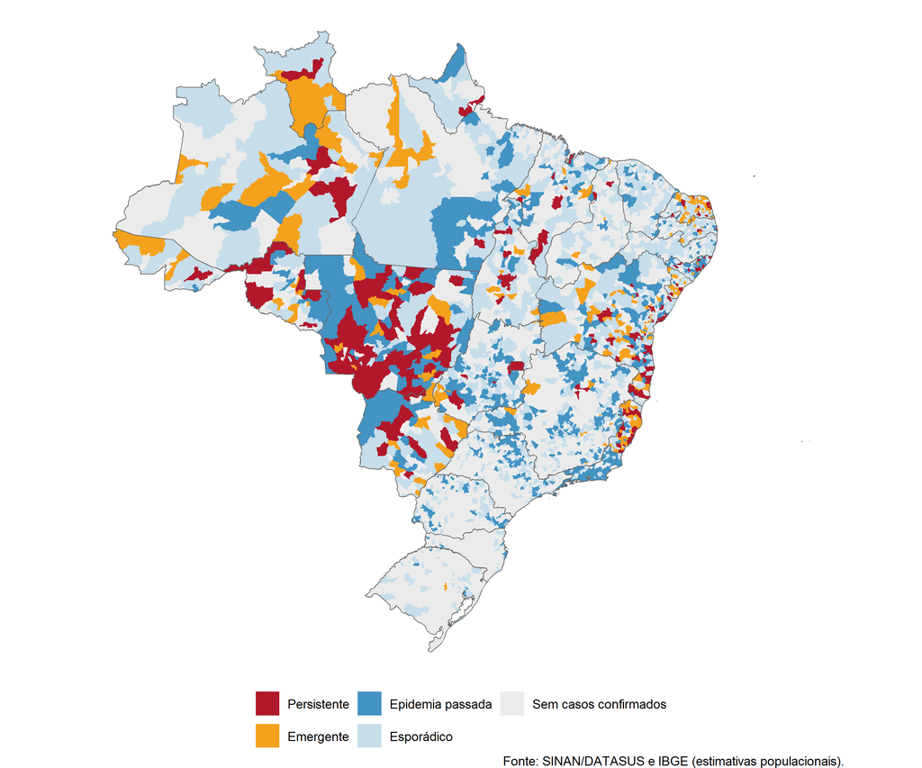

Figura. Tipologia dos municípios brasileiros segundo a trajetória da zika.

Tabela. Municípios emergentes com maior incidência recente de zika.

| Município | UF | Casos na epidemia | Casos recentes | Incidência média anual recente (/100 mil) |
| --- | --- | --- | --- | --- |
| Itaúba | MT | 0 | 204 | 1.307,4 |
| Pedra Grande | RN | 0 | 71 | 633,5 |
| Novo São Joaquim | MT | 1 | 74 | 340,7 |
| São José do Rio Claro | MT | 1 | 68 | 156,8 |
| Cascalho Rico | MG | 0 | 12 | 145,4 |
| São Desidério | BA | 2 | 151 | 143,9 |
| Barrolândia | TO | 0 | 19 | 129,5 |
| Baía Formosa | RN | 0 | 35 | 128,0 |
| Guiratinga | MT | 1 | 37 | 120,3 |
| Arês | RN | 0 | 41 | 99,9 |

Foram identificados **200 municípios emergentes**, onde vivem 6.771.419 pessoas, e **178 municípios com transmissão persistente**. Os emergentes quase não registraram casos durante a epidemia, então é provável que sua população tenha baixa imunidade ao vírus. Isso os torna prioritários para o controle vetorial e para o acompanhamento de gestantes.

# 8 Perfil dos casos confirmados

Tabela 3. Características sociodemográficas dos casos confirmados de zika. Brasil.

| Variável | Categoria | n | % |
| --- | --- | --- | --- |
| Sexo | Feminino | 129.406 | 67,0 |
|  | Ignorado | 291 | 0,2 |
|  | Masculino | 63.523 | 32,9 |
| Faixa etária (anos) | 0–4 | 11.082 | 5,7 |
|  | 12–17 | 15.532 | 8,0 |
|  | 18–29 | 49.179 | 25,5 |
|  | 30–39 | 39.803 | 20,6 |
|  | 40–49 | 27.956 | 14,5 |
|  | 50–59 | 20.143 | 10,4 |
|  | 5–11 | 13.003 | 6,7 |
|  | 60–69 | 10.660 | 5,5 |
|  | 70+ | 5.857 | 3,0 |
|  | Sem informação | 5 | 0,0 |
| Raça/cor | Amarela | 1.402 | 0,7 |
|  | Branca | 40.062 | 20,7 |
|  | Ignorado | 57.578 | 29,8 |
|  | Indígena | 575 | 0,3 |
|  | Parda | 68.223 | 35,3 |
|  | Preta | 7.367 | 3,8 |
|  | Sem informação | 18.013 | 9,3 |

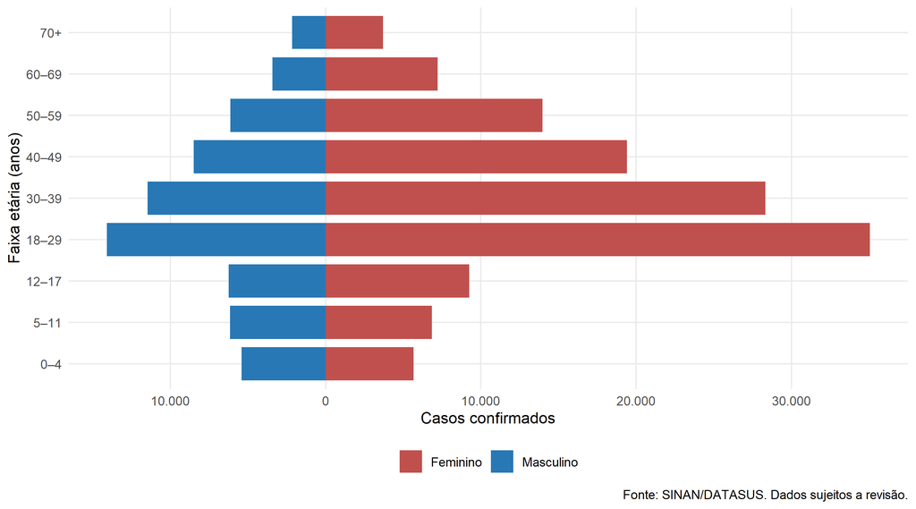

Figura 5. Casos confirmados de zika por sexo e faixa etária. Brasil.

Podemos notar que o perfil mais comum são **Mulheres em Idade Fértil**. O que é um grande problema, já que a maior intercorrência relacionada a Zika é a microcefalia.

# 9 Zika em gestantes

Tabela 4. Casos confirmados de zika em mulheres de 10 a 49 anos, segundo situação gestacional. Brasil.

| Situação gestacional | n | % |
| --- | --- | --- |
| 1º trimestre | 3.948 | 4,2 |
| 2º trimestre | 6.374 | 6,8 |
| 3º trimestre | 5.456 | 5,8 |
| Idade gestacional ignorada | 522 | 0,6 |
| Ignorado | 18.867 | 20,0 |
| Não gestante | 50.132 | 53,2 |
| Não se aplica | 8.872 | 9,4 |

A completude dos dados dificulta a análise. Mas podemos ver que o diagnóstico é mais comum a partir do 2º Trimestre.

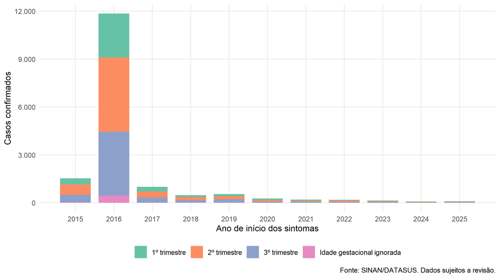

Figura 6. Casos confirmados de zika em gestantes, segundo idade gestacional, por ano de início dos sintomas. Brasil.

# 10 Evolução dos casos

Tabela 5. Evolução dos casos confirmados de zika. Brasil.

| Evolução | n | % |
| --- | --- | --- |
| Cura | 181.701 | 94,0 |
| Ignorado | 6.097 | 3,2 |
| Sem informação | 5.268 | 2,7 |
| Óbito por outras causas | 80 | 0,0 |
| Óbito pelo agravo | 74 | 0,0 |

No período foram registrados **74 óbitos pelo agravo** entre os casos confirmados, o que corresponde a uma letalidade de **0,038%**.

Ou seja, a letalidade é baixa. Mas como citado anteriormente, o problema maior que a Zika causa é a microcefalia. Não temos dados para identificar quais dos casos tiveram este desfecho.

# 11 Oportunidade da notificação

Tabela 6. Tempo entre o início dos sintomas e a notificação de zika, por ano. Brasil.

| Ano | Registros | Mediana (dias) | IIQ (dias) | % em até 7 dias |
| --- | --- | --- | --- | --- |
| 2015 | 56.159 | 2 | 1–5 | 83,0 |
| 2016 | 273.904 | 2 | 1–5 | 85,4 |
| 2017 | 31.789 | 3 | 1–6 | 81,4 |
| 2018 | 20.073 | 4 | 2–8 | 72,3 |
| 2019 | 30.527 | 4 | 1–7 | 77,9 |
| 2020 | 20.628 | 4 | 2–7 | 76,5 |
| 2021 | 19.750 | 4 | 2–8 | 71,1 |
| 2022 | 35.805 | 4 | 2–7 | 79,7 |
| 2023 | 36.061 | 3 | 2–6 | 82,3 |
| 2024 | 43.319 | 3 | 2–6 | 83,9 |
| 2025 | 25.696 | 3 | 2–6 | 81,8 |

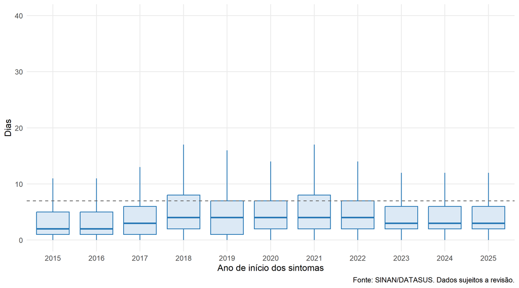

Figura 7. Distribuição do tempo (dias) entre o início dos sintomas e a notificação, por ano. Brasil.

# 12 Qualidade dos dados

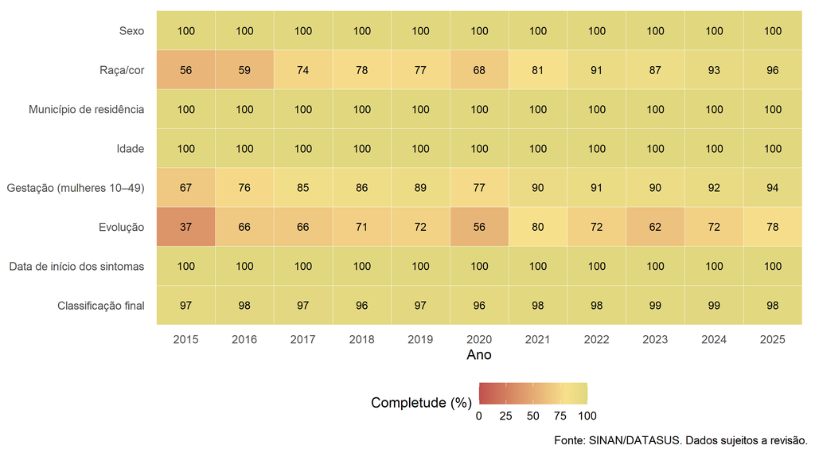

Figura 8. Completude (%) de variáveis selecionadas das notificações de zika, por ano. Brasil.

Em todo o período, o campo **raça/cor** teve 70,0% de preenchimento válido.

O campo Evolução teve uma baixa taxa de preenchimento. Isso implica que os desfechos registrados podem não representar adequadamente todos os casos. Isso limita análises sobre cura, óbito e outros desfechos.

E o campo Gestação foi melhorando o preenchimento ao longo da série. Isso compromete análises, principalmente no período da epidemia.

# 13 Considerações finais

Entre 2015 e 2025, a zika teve seu maior volume de notificações em 2016, com incidência de 67,0 casos confirmados por 100 mil habitantes. Em 2025, a incidência foi de 0,88/100 mil. A distribuição mensal mostra o padrão sazonal das notificações ao longo do ano (Figura 3), e o padrão espacial está na Figura 4.

**Limitações**

- **Subnotificação.** Uma alta proporção de infecções é assintomática ou leve, e esses casos tendem a não procurar atendimento.
- **Diagnóstico.** Os sintomas se sobrepõem aos da dengue e da chikungunya. Também há reação cruzada sorológica entre flavivírus e muitos casos são confirmados por critério clínico-epidemiológico.
- **Dados recentes.** Os anos mais recentes podem estar preliminares e sujeitos a revisão.
- **Completude.** O preenchimento é incompleto em variáveis como raça/cor, evolução e situação gestacional.
- **População.** As estimativas populacionais foram interpoladas nos anos sem dados oficiais.
- **Desfechos congênitos.** A síndrome congênita do Zika não é registrada nesta ficha do SINAN, e seus desfechos não estão representados aqui.

**Recomendações**

- Fortalecer o controle vetorial integrado com dengue e chikungunya, intensificando as ações antes do período sazonal.
- Priorizar a investigação laboratorial e o acompanhamento de gestantes com suspeita de zika.
- Qualificar o preenchimento das fichas, principalmente evolução, raça/cor e situação gestacional.
- Aumentar a proporção de notificações feitas em até 7 dias do início dos sintomas.

*Notas técnicas: dados do SINAN extraídos via `microdatasus`. População das estimativas do IBGE (SIDRA 6579) e malhas territoriais do IBGE (2020) via `geobr`. Processado em 19/10/2026 22:01.* *Nota: na base do SINAN, o código de óbito pelo agravo aparece rotulado como “Óbito por dengue”, herdado da ficha de arboviroses. Esses registros foram considerados óbitos pelo agravo notificado (zika).*